# IM9_PSMA3

## Подготовка данных

```r
raw_data <- fread("raw_data.csv")
raw_data$Total_score <- as.numeric(sapply(raw_data$Total_score, function(x) sub(",", ".", x)))
raw_data$Unused_score <- as.numeric(sapply(raw_data$Unused_score, function(x) sub(",", ".", x)))
raw_data$`% Cov` <- as.numeric(sapply(raw_data$`% Cov`, function(x) sub(",", ".", x)))
raw_data$`% Cov (95)` <- as.numeric(sapply(raw_data$`% Cov (95)`, function(x) sub(",", ".", x)))
raw_data$Accession <- sapply(raw_data$Accession, function(x) unlist(strsplit(x, "|", fixed = T))[2])
setnames(raw_data, "Accession", "Uniprot")
#Удаляем белки C unused score < 1.3
raw_data <- raw_data[raw_data$Unused_score >= 1.3]
```

## Аннотация по Gene Ontology

```r
# define biomart object
mart <- useMart(biomart = "ensembl", dataset = "hsapiens_gene_ensembl")

# query biomart
BM_out <- getBM(attributes = c("name_1006", "namespace_1003", "hgnc_symbol", "uniprotswissprot"),
                 filters = "uniprotswissprot",
                values = raw_data$Uniprot,
                mart = mart,
                uniqueRows = TRUE)

#Удаляем неинформативные GO
BM_out <- BM_out[BM_out$name_1006 != "molecular_function" &
                  BM_out$name_1006 != "cellular_component" &
                   BM_out$name_1006 != "biological_process" ,]

BM_out <- as.data.table(BM_out)

mol_function <- BM_out[namespace_1003 == "molecular_function", .(uniprotswissprot, hgnc_symbol, name_1006)]
mol_function[, mol_function := .(list(name_1006)), by=uniprotswissprot]
mol_function[, name_1006 := NULL]
mol_function <- mol_function[!duplicated(mol_function)]

cell_component <- BM_out[namespace_1003 == "cellular_component", .(uniprotswissprot, hgnc_symbol, name_1006)]
cell_component[, cell_component := .(list(name_1006)), by=uniprotswissprot]
cell_component[, name_1006 := NULL]
cell_component <- cell_component[!duplicated(cell_component)]

bio_process <- BM_out[namespace_1003 == "biological_process", .(uniprotswissprot, hgnc_symbol, name_1006)]
bio_process[, bio_process := .(list(name_1006)), by=uniprotswissprot]
bio_process[, name_1006 := NULL]
bio_process <- bio_process[!duplicated(bio_process)]

GO_data <- merge(mol_function, cell_component)
GO_data <- merge(GO_data, bio_process)

setnames(GO_data, "uniprotswissprot", "Uniprot")

final_data <- merge(raw_data, GO_data, by = "Uniprot")

rm(BM_out, mol_function, cell_component, bio_process, GO_data, raw_data)
```

Отфильтруем все то, что нас не интересует

```r
unique(final_data$Cell_line)
```

```
## [1] "Im9"      "RPMI8226"
```

```r
final_data <- final_data[Proteome_type == "PSMA3", ]
final_data <- final_data[Cell_line == "Im9", ]
```

Взглянем на то, что есть

```r
final_data[, .N, by =. (Treatment, Compartment)]
```

```
##    Treatment Compartment   N
## 1:         K           C 132
## 2:        FC           N 184
## 3:         K           N 299
## 4:        FC           C  50
## 5:       CmB           N  33
## 6:        RB           N  39
## 7:       CmB           C  29
## 8:        RB           C  26
```

Разделим датасет на 3 части - по обработке, чтоб в каждом был контроль и опыт

```r
CmB_dataset <- final_data[Treatment %in% c("CmB", "K")]
nrow(CmB_dataset)
```

```
## [1] 493
```

```r
RB_dataset <- final_data[Treatment %in% c("RB", "K")]
nrow(RB_dataset)
```

```
## [1] 496
```

```r
FC_dataset <- final_data[Treatment %in% c("FC", "K")]
nrow(FC_dataset)
```

```
## [1] 665
```

## CmB обработка

### Общие для контроля и опыта белочки.

```r
common_CmB <- intersect(CmB_dataset[Treatment == "K", hgnc_symbol],
                        CmB_dataset[Treatment == "CmB", hgnc_symbol])
common_CmB
```

```
##  [1] "NUDT21"    "LANCL1"    "TUBB"      "HNRNPC"    "HSP90AB1"
##  [6] "SNRNP70"   "RPSA"      "HNRNPA1"   "HSPA8"     "PABPC1"
## [11] "CBR1"      "HNRNPA2B1" "PSMA3"     "EEF1G"     "HNRNPH3"
## [16] "HNRNPH1"   "EIF3B"     "EIF4A1"    "HNRNPK"    "SNRPD3"
## [21] "RPS4X"     "ACTG1"     "EEF1A1"    "TUBB4B"    "HNRNPU"
## [26] "EIF3A"     "SF3B3"     "UBAP2"     "CCAR2"     "HNRNPUL1"
## [31] "SRRT"      "XRN2"      "EIF3L"
```

Их мало - всего 33 штук!

Кто они у нас по функциям - Cмотрим в msigDB - топ 10 функций

33 белков совершенно несерьезно по взаимодействиям расписывать

Gene Set Name FDR q-value HSIAO_HOUSEKEEPING_GENES 1.02E-15 GO_INTERSPECIES_INTERACTION_BETWEEN_ORGANISMS 1.99E-14 GO_RNA_BINDING 2.19E-14 PUJANA_BRCA1_PCC_NETWORK 3.03E-14 GO_POLY_A_RNA_BINDING 4.56E-14 CASORELLI_ACUTE_PROMYELOCYTIC_LEUKEMIA_DN 2.85E-13 GO_RIBONUCLEOPROTEIN_COMPLEX 2.68E-11 GO_MRNA_METABOLIC_PROCESS 1.03E-10 HALLMARK_MYC_TARGETS_V1 1.05E-10 GO_MACROMOLECULAR_COMPLEX_BINDING 2.25E-10

Видим housekeeping - в принципе, понятно, откуда он взялся

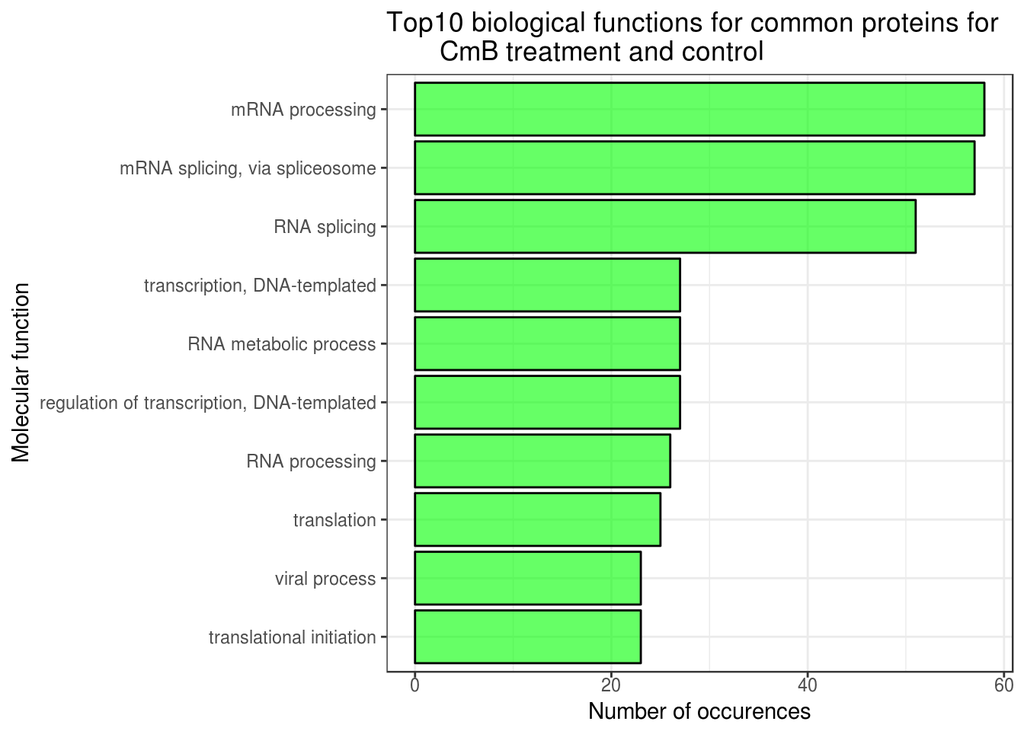

```r
bp_list <- final_data[hgnc_symbol %in% common_CmB, bio_process]
bp_list <- bp_list[!duplicated(bp_list)]
total_bp <- data.table(table(unlist(bp_list)))
total_bp <- total_bp[order(total_bp$N, decreasing = T), ]

ggplot(total_bp[1:10], aes(x=reorder(V1,N), N))+
  geom_bar(stat = "identity", colour = "black", fill = "green", alpha = "0.6")+
  labs(title = "Top10 biological functions for common proteins for
       CmB treatment and control",
       x = "Molecular function",
       y = "Number of occurences")+
  theme_grey() %+replace%
  theme(panel.background = element_rect(fill = "white", colour = NA),
        panel.border = element_rect(fill = NA, colour = "grey20"),
        panel.grid.major = element_line(colour = "grey92"),
        panel.grid.minor = element_line(colour = "grey92", size = 0.25),
        strip.background = element_rect(fill = "grey85", colour = "grey20"),
        legend.key = element_rect(fill = "white", colour = NA),
        axis.text.x = element_text(angle = 0, hjust = 0.5),
        complete = TRUE) +
  coord_flip()
```

### Пропадают после обработки

```r
unique_K <- setdiff(CmB_dataset[Treatment == "K", hgnc_symbol], CmB_dataset[Treatment == "CmB", hgnc_symbol])
unique_K
```

```
##   [1] "RBM47"     "MYO1G"     "AIP"       "PGRMC1"    "DDX3X"
##   [6] "COPE"      "SCAMP3"    "UQCRQ"     "HNRNPDL"   "XPO1"
##  [11] "PGRMC2"    "DHX15"     "CYB5B"     "PHGDH"     "HNRNPR"
##  [16] "NDUFA2"    "IDH3B"     "PLIN3"     "LPXN"      "CTNND1"
##  [21] "NDUFS2"    "H2AFY"     "SEC22B"    "PSIP1"     "NDUFS3"
##  [26] "SF3B1"     "SNRNP200"  "NUP155"    "RSL1D1"    "MTA2"
##  [31] "TOMM70"    "PRPF6"     "LETM1"     "AP2A1"     "AIFM1"
##  [36] "NDUFB10"   "TOMM40"    "CYB5A"     "GLUD1"     "MT-CO2"
##  [41] "PGK1"      "HLA-A"     "HLA-DRA"   "LMNA"      "TFRC"
##  [46] "VTN"       "HLA-DPB1"  "HSPB1"     "RPN1"      "RPN2"
##  [51] "GNAI2"     "ATP1A1"    "SLC25A5"   "RPLP1"     "ATP5F1B"
##  [56] "ENO1"      "FCER2"     "NPM1"      "EPRS"      "HSP90AA1"
##  [61] "ANXA6"     "SLC3A2"    "CYC1"      "PTPRC"     "SNRPB2"
##  [66] "VIM"       "CD48"      "PARP1"     "ALDOC"     "HIST1H1E"
##  [71] "HSPD1"     "HSPA5"     "MTHFD1"    "XRCC6"     "XRCC5"
```

[output cut: 54 more lines]

Ого, Cколько их! их аж 341 штуки!

Что у нас в STRING для этих ребят есть?

https://string-db.org/cgi/network.pl?taskId=HKtEUUSMTuSJ

Их много, много РНК-связывания. Надо смотреть на белки, которые и там и там участвуют. Тут это EIF4A3 и UBA52

Сколько в среднем пептидов для всех этих белков нашлось?

```r
summary(CmB_dataset[hgnc_symbol %in% unique_K, `Peptides(95%)`]) #для большинства - по одному пептидику, но есть те, кого прям совсем много, кто же это?
```

```
##    Min. 1st Qu.  Median    Mean 3rd Qu.    Max.
##    0.00    1.00    1.00    2.46    3.00   29.00
```

```r
CmB_dataset[`Peptides(95%)` == 29, hgnc_symbol]
```

```
## [1] "ACTB"
```

Все понятно, едем дальше

Барплот для них

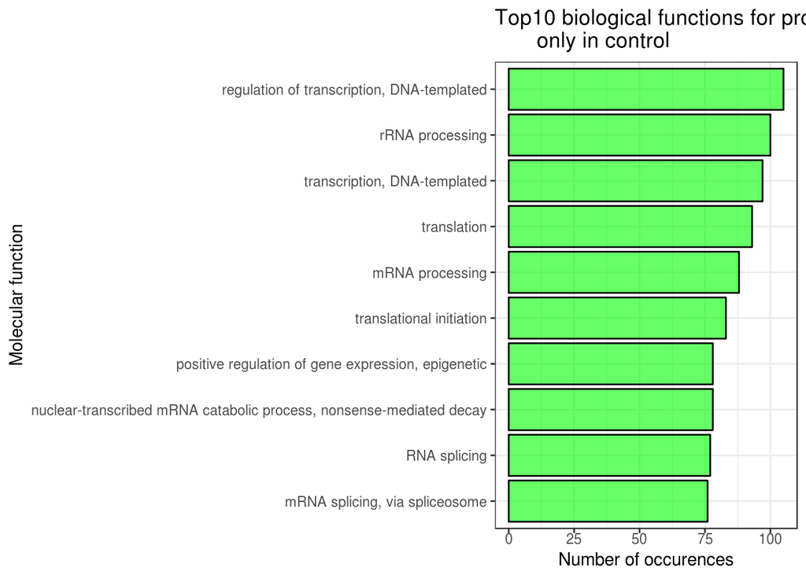

```r
bp_list <- final_data[hgnc_symbol %in% unique_K, bio_process]
bp_list <- bp_list[!duplicated(bp_list)]
total_bp <- data.table(table(unlist(bp_list)))
total_bp <- total_bp[order(total_bp$N, decreasing = T), ]

ggplot(total_bp[1:10], aes(x=reorder(V1,N), N))+
  geom_bar(stat = "identity", colour = "black", fill = "green", alpha = "0.6")+
  labs(title = "Top10 biological functions for proteins present
       only in control",
       x = "Molecular function",
       y = "Number of occurences")+
  theme_grey() %+replace%
  theme(panel.background = element_rect(fill = "white", colour = NA),
        panel.border = element_rect(fill = NA, colour = "grey20"),
        panel.grid.major = element_line(colour = "grey92"),
        panel.grid.minor = element_line(colour = "grey92", size = 0.25),
        strip.background = element_rect(fill = "grey85", colour = "grey20"),
        legend.key = element_rect(fill = "white", colour = NA),
        axis.text.x = element_text(angle = 0, hjust = 0.5),
        complete = TRUE) +
  coord_flip()
```

### Появляются после обработки

```r
unique_Cmb <- setdiff(CmB_dataset[Treatment == "CmB", hgnc_symbol], CmB_dataset[Treatment == "K", hgnc_symbol])
unique_Cmb
```

```
## [1] "PAX4"   "ZNF207" "UGDH"   "SNRPE"  "SNRPD1" "TUBA1B" "EWSR1"  "SF1"
## [9] "HRNR"
```

Их всего - 9 - это вообще несерьезно

Сколько для них пептидов?

```r
CmB_dataset[hgnc_symbol %in% unique_Cmb, `Peptides(95%)`] #разве что один нормально, да и тот тубулин
```

```
##  [1] 1 1 2 1 1 8 1 1 1 1 1
```

Поэтому, будем считать, что их просто нет.

Но столбики мы таки построим

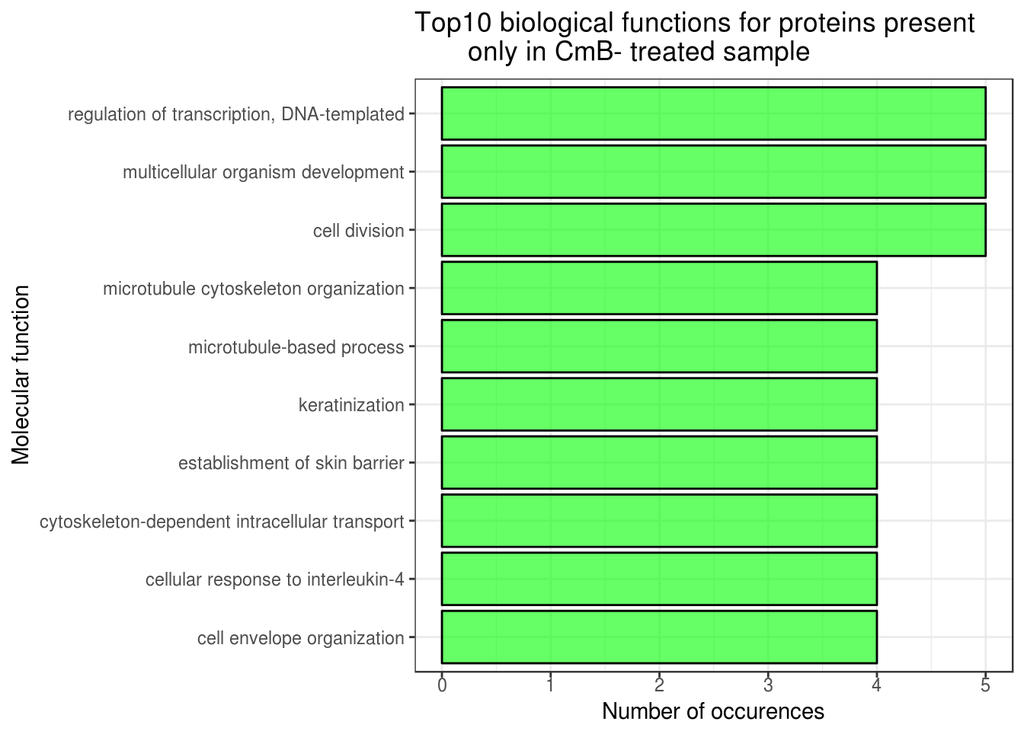

```r
bp_list <- final_data[hgnc_symbol %in% unique_Cmb, bio_process]
bp_list <- bp_list[!duplicated(bp_list)]
total_bp <- data.table(table(unlist(bp_list)))
total_bp <- total_bp[order(total_bp$N, decreasing = T), ]

ggplot(total_bp[1:10], aes(x=reorder(V1,N), N))+
  geom_bar(stat = "identity", colour = "black", fill = "green", alpha = "0.6")+
  labs(title = "Top10 biological functions for proteins present
       only in CmB- treated sample",
       x = "Molecular function",
       y = "Number of occurences")+
  theme_grey() %+replace%
  theme(panel.background = element_rect(fill = "white", colour = NA),
        panel.border = element_rect(fill = NA, colour = "grey20"),
        panel.grid.major = element_line(colour = "grey92"),
        panel.grid.minor = element_line(colour = "grey92", size = 0.25),
        strip.background = element_rect(fill = "grey85", colour = "grey20"),
        legend.key = element_rect(fill = "white", colour = NA),
        axis.text.x = element_text(angle = 0, hjust = 0.5),
        complete = TRUE) +
  coord_flip()
```

### Ядро-цитоплазма

Значит, агент сmB портит что-то в связи, и теперь за PSMA3 пути они не вытаскиваются.

Там на картинке есть 2 кластера плотных во взаимодействиях, и это говорит о том, что у нас есть группы белков, которые участвуют в разных вещах - это трансляция и сплайсинг - и то, и другое завязано на РНК.

Попробуем посмотреть только для цитоплазматические белочки из тех, которые пропадают

```r
temp_K <- CmB_dataset[Treatment == "K"]
temp_K <- temp_K[Compartment == "C", hgnc_symbol]

temp_CmB <- CmB_dataset[Treatment == "CmB"]
temp_CmB <- temp_CmB[Compartment == "C", hgnc_symbol]

unique_K_cp <- setdiff(temp_K, temp_CmB)
rm(temp_K, temp_CmB)
unique_K_cp
```

```
##   [1] "RBM47"    "AIP"      "DDX3X"    "COPE"     "SCAMP3"   "HNRNPDL"
##   [7] "XPO1"     "PLIN3"    "LPXN"     "PGK1"     "HLA-A"    "HLA-DRA"
##  [13] "HSPB1"    "GNAI2"    "ENO1"     "EPRS"     "HSP90AA1" "ANXA6"
##  [19] "VIM"      "HNRNPA1"  "ALDOC"    "HSPD1"    "HSPA5"    "MTHFD1"
##  [25] "XRCC5"    "EEF2"     "HLA-DRB1" "LCP1"     "PKM"      "RPS2"
##  [31] "YBX3"     "PSMC3"    "RPL7"     "MYL12A"   "NCL"      "MX1"
##  [37] "PAICS"    "UBA1"     "PSMA1"    "RPL10"    "CAD"      "CANX"
##  [43] "DNAJA1"   "YWHAB"    "MYH9"     "COPB2"    "HSPA9"    "RPS19"
##  [49] "RPL35"    "RPS9"     "RPS5"     "CAPZB"    "PRRC2A"   "LMAN1"
##  [55] "NASP"     "FASN"     "CCT8"     "RAB7A"    "COPA"     "CSE1L"
##  [61] "TPI1"     "ACTB"     "RAB14"    "RAP1B"    "RPS3A"    "RPL26"
##  [67] "YWHAG"    "RPS16"    "RPS18"    "RPS13"    "RAN"      "TUBA4A"
##  [73] "HBA2"     "EIF4G2"   "PURA"     "EIF4G1"   "PRDX1"    "BAX"
##  [79] "TRAP1"    "PSMD2"    "TRIM28"   "TUBA3C"   "EIF4A2"   "KPNB1"
##  [85] "PSMD6"    "PDIA6"    "PMVK"     "PCBP2"    "NSDHL"    "RAB11B"
##  [91] "PDCD4"    "ECPAS"    "ATL3"     "TUBA1A"   "FERMT3"   "CARM1"
##  [97] "NUDCD3"   "GCN1"     "ABHD14B"  "EIF3C"    "SRRT"     "LDAH"
## [103] "ATXN10"   "PSME2"    "CORO1C"   "RUVBL2"   "RUVBL1"   "NUDC"
## [109] "LUC7L2"   "COPG1"
```

Их всего - 110

Вот тебе картинка - тут несколько кластеров, но дельный - только трансляция

https://string-db.org/cgi/network.pl?taskId=5lXzAOtydvu0

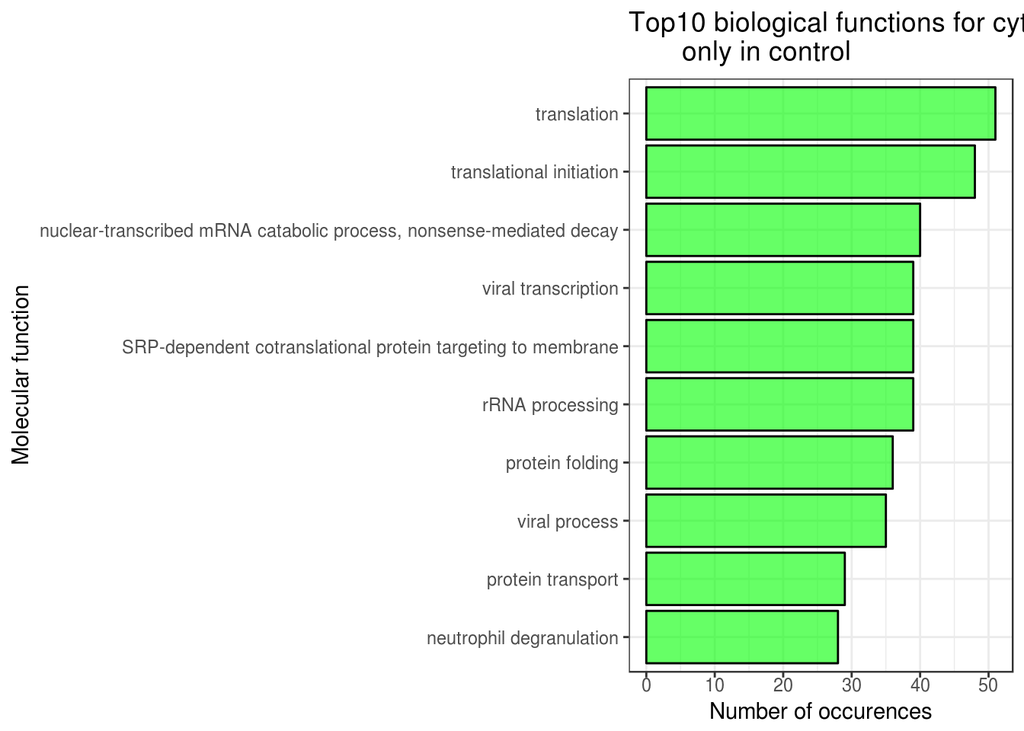

```r
bp_list <- final_data[hgnc_symbol %in% unique_K_cp, bio_process]
bp_list <- bp_list[!duplicated(bp_list)]
total_bp <- data.table(table(unlist(bp_list)))
total_bp <- total_bp[order(total_bp$N, decreasing = T), ]

ggplot(total_bp[1:10], aes(x=reorder(V1,N), N))+
  geom_bar(stat = "identity", colour = "black", fill = "green", alpha = "0.6")+
  labs(title = "Top10 biological functions for cytoplasmic proteins present
       only in control",
       x = "Molecular function",
       y = "Number of occurences")+
  theme_grey() %+replace%
  theme(panel.background = element_rect(fill = "white", colour = NA),
        panel.border = element_rect(fill = NA, colour = "grey20"),
        panel.grid.major = element_line(colour = "grey92"),
        panel.grid.minor = element_line(colour = "grey92", size = 0.25),
        strip.background = element_rect(fill = "grey85", colour = "grey20"),
        legend.key = element_rect(fill = "white", colour = NA),
        axis.text.x = element_text(angle = 0, hjust = 0.5),
        complete = TRUE) +
  coord_flip()
```

Теперь cделаем только для ядерных белочков

```r
temp_K <- CmB_dataset[Treatment == "K"]
temp_K <- temp_K[Compartment == "N", hgnc_symbol]

temp_CmB <- CmB_dataset[Treatment == "CmB"]
temp_CmB <- temp_CmB[Compartment == "N", hgnc_symbol]

unique_K_nuc <- setdiff(temp_K, temp_CmB)
rm(temp_K, temp_CmB)
unique_K_nuc
```

```
##   [1] "MYO1G"     "PGRMC1"    "SCAMP3"    "UQCRQ"     "HNRNPDL"
##   [6] "PGRMC2"    "DHX15"     "CYB5B"     "PHGDH"     "HNRNPR"
##  [11] "NDUFA2"    "IDH3B"     "CTNND1"    "NDUFS2"    "H2AFY"
##  [16] "SEC22B"    "PSIP1"     "NDUFS3"    "SF3B1"     "SNRNP200"
##  [21] "NUP155"    "RSL1D1"    "MTA2"      "TOMM70"    "PRPF6"
##  [26] "LETM1"     "AP2A1"     "AIFM1"     "NDUFB10"   "TOMM40"
##  [31] "CYB5A"     "GLUD1"     "MT-CO2"    "HLA-A"     "HLA-DRA"
##  [36] "LMNA"      "TFRC"      "VTN"       "HLA-DPB1"  "RPN1"
##  [41] "RPN2"      "GNAI2"     "ATP1A1"    "SLC25A5"   "RPLP1"
##  [46] "ATP5F1B"   "FCER2"     "NPM1"      "TUBB"      "SLC3A2"
##  [51] "HSP90AB1"  "CYC1"      "PTPRC"     "SNRPB2"    "VIM"
##  [56] "RPSA"      "CD48"      "PARP1"     "HIST1H1E"  "HSPD1"
##  [61] "HSPA5"     "HSPA8"     "XRCC6"     "XRCC5"     "COX4I1"
##  [66] "EEF2"      "HLA-DRB1"  "LCP1"      "CD59"      "HSP90B1"
##  [71] "HNRNPL"    "HIST1H1B"  "POR"       "ATP2A2"    "DDX5"
```

[output cut: 42 more lines]

Их вcего - 283 - больше, чем цитоплазматичеcких

https://string-db.org/cgi/network.pl?taskId=CUGnfHTXeqkq - я удалил из состава вершин убиквитин, потому что он ко всему лепится Обрати внимание на EIF4A3

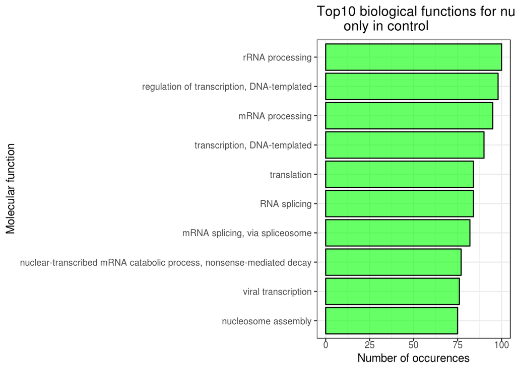

```r
bp_list <- final_data[hgnc_symbol %in% unique_K_nuc, bio_process]
bp_list <- bp_list[!duplicated(bp_list)]
total_bp <- data.table(table(unlist(bp_list)))
total_bp <- total_bp[order(total_bp$N, decreasing = T), ]

ggplot(total_bp[1:10], aes(x=reorder(V1,N), N))+
  geom_bar(stat = "identity", colour = "black", fill = "green", alpha = "0.6")+
  labs(title = "Top10 biological functions for nuclear proteins present
       only in control",
       x = "Molecular function",
       y = "Number of occurences")+
  theme_grey() %+replace%
  theme(panel.background = element_rect(fill = "white", colour = NA),
        panel.border = element_rect(fill = NA, colour = "grey20"),
        panel.grid.major = element_line(colour = "grey92"),
        panel.grid.minor = element_line(colour = "grey92", size = 0.25),
        strip.background = element_rect(fill = "grey85", colour = "grey20"),
        legend.key = element_rect(fill = "white", colour = NA),
        axis.text.x = element_text(angle = 0, hjust = 0.5),
        complete = TRUE) +
  coord_flip()
```

### Вывод

Можно сказать, что Cmb действует на трансляцию в цитоплазме

И, видимо, на ядрышко, потому видим с кучу HNRNP и рибосомных белков

Как работает Cmb? Вся причина, скорее всего, в каком-то белке, который входит в оба плотных скопления на графе и когда в нем что-то портится, связывание теряется и белков больше нет в пробе. Для этого вещества этот белок - EIF4A3, скорее всего

Ищешь домен, с кем именно Cmb вяжется - читаешь литературу - пишешь в обсуждение))

## RB обработка

### Белочки, встречающиеся и там и там, с ними связывание не теряется.

```r
common_RB <- intersect(RB_dataset[Treatment == "K", hgnc_symbol],
                        RB_dataset[Treatment == "RB", hgnc_symbol])
common_RB
```

```
##  [1] "HNRNPR"    "NUDT21"    "LMNA"      "NPM1"      "TUBB"
##  [6] "HSP90AA1"  "HNRNPC"    "HSP90AB1"  "SNRNP70"   "HNRNPA1"
## [11] "HSPA8"     "PABPC1"    "RPS2"      "CBR1"      "HNRNPA2B1"
## [16] "SFPQ"      "PSMA3"     "HNRNPH3"   "HNRNPH1"   "MYH9"
## [21] "RBMX"      "HNRNPA3"   "EIF3B"     "EIF4A1"    "HNRNPK"
## [26] "SNRPD3"    "HIST1H4I"  "ACTG1"     "TUBB4B"    "EIF4G2"
## [31] "SRSF3"     "HNRNPU"    "TUBA3C"    "EIF3A"     "ELAVL1"
## [36] "CCAR2"     "EIF3C"     "HNRNPAB"   "HNRNPUL1"  "SRRT"
## [41] "XRN2"
```

Их вcего - 41

Вот что по msigdb

Gene Set Name FDR q-value GO_POLY_A_RNA_BINDING 8.88E-41 GO_RNA_BINDING 7.51E-39 GO_RNA_SPLICING_VIA_TRANSESTERIFICATION_REACTIONS 2.07E-31 GO_MRNA_METABOLIC_PROCESS 3.83E-30 GO_MRNA_PROCESSING 1.91E-29 GO_RNA_SPLICING 7.07E-29 GO_RIBONUCLEOPROTEIN_COMPLEX 8.89E-27 GO_RNA_PROCESSING 1.97E-25 REACTOME_MRNA_SPLICING 1.67E-24 REACTOME_PROCESSING_OF_CAPPED_INTRON_CONTAINING_PRE_MRNA 4.6E-23

Все, кроме явной контаминации - типа тубулина, актина, ламинов и PSMA3 - имеют РНК-связывающую функцию

Есть PSMA3- что тоже хорошо, говорит о том, что GST случился

Сеть говорит о том, что у нас здесь только процесс процессинга РНК в общем-то https://string-db.org/cgi/network.pl?taskId=LKQLplgeoqQc

Раз он и там и там есть есть, то, значит, RB на связывание не очень влияет

Столбики

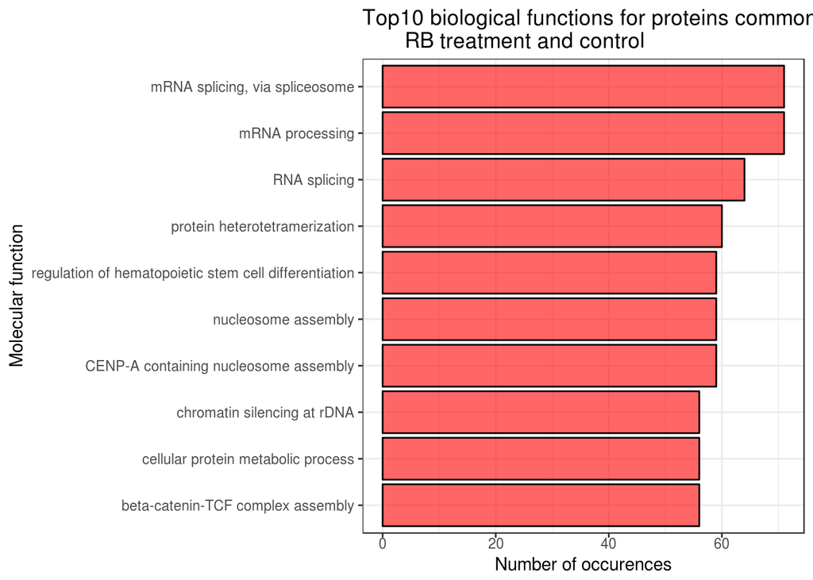

```r
bp_list <- final_data[hgnc_symbol %in% common_RB, bio_process]
bp_list <- bp_list[!duplicated(bp_list)]
total_bp <- data.table(table(unlist(bp_list)))
total_bp <- total_bp[order(total_bp$N, decreasing = T), ]

ggplot(total_bp[1:10], aes(x=reorder(V1,N), N))+
  geom_bar(stat = "identity", colour = "black", fill = "red", alpha = "0.6")+
  labs(title = "Top10 biological functions for proteins common for
       RB treatment and control",
       x = "Molecular function",
       y = "Number of occurences")+
  theme_grey() %+replace%
  theme(panel.background = element_rect(fill = "white", colour = NA),
        panel.border = element_rect(fill = NA, colour = "grey20"),
        panel.grid.major = element_line(colour = "grey92"),
        panel.grid.minor = element_line(colour = "grey92", size = 0.25),
        strip.background = element_rect(fill = "grey85", colour = "grey20"),
        legend.key = element_rect(fill = "white", colour = NA),
        axis.text.x = element_text(angle = 0, hjust = 0.5),
        complete = TRUE) +
  coord_flip()
```

### Пропадают после обработки

```r
unique_K_RB <- setdiff(RB_dataset[Treatment == "K", hgnc_symbol], RB_dataset[Treatment == "RB", hgnc_symbol])
unique_K_RB
```

```
##   [1] "RBM47"     "MYO1G"     "AIP"       "PGRMC1"    "DDX3X"
##   [6] "COPE"      "SCAMP3"    "UQCRQ"     "HNRNPDL"   "XPO1"
##  [11] "PGRMC2"    "DHX15"     "CYB5B"     "PHGDH"     "NDUFA2"
##  [16] "LANCL1"    "IDH3B"     "PLIN3"     "LPXN"      "CTNND1"
##  [21] "NDUFS2"    "H2AFY"     "SEC22B"    "PSIP1"     "NDUFS3"
##  [26] "SF3B1"     "SNRNP200"  "NUP155"    "RSL1D1"    "MTA2"
##  [31] "TOMM70"    "PRPF6"     "LETM1"     "AP2A1"     "AIFM1"
##  [36] "NDUFB10"   "TOMM40"    "CYB5A"     "GLUD1"     "MT-CO2"
##  [41] "PGK1"      "HLA-A"     "HLA-DRA"   "TFRC"      "VTN"
##  [46] "HLA-DPB1"  "HSPB1"     "RPN1"      "RPN2"      "GNAI2"
##  [51] "ATP1A1"    "SLC25A5"   "RPLP1"     "ATP5F1B"   "ENO1"
##  [56] "FCER2"     "EPRS"      "ANXA6"     "SLC3A2"    "CYC1"
##  [61] "PTPRC"     "SNRPB2"    "VIM"       "RPSA"      "CD48"
##  [66] "PARP1"     "ALDOC"     "HIST1H1E"  "HSPD1"     "HSPA5"
##  [71] "MTHFD1"    "XRCC6"     "XRCC5"     "COX4I1"    "EEF2"
```

[output cut: 52 more lines]

Ого, Cколько их! их аж 333 штук!

Сетка для этих ребят: https://string-db.org/cgi/network.pl?taskId=nMG7bC7FM8Xl - я опять убрал убиквитин

Есть отличия от CmB, но в целом похоже, тоже ядрышко, тоже рибосомы

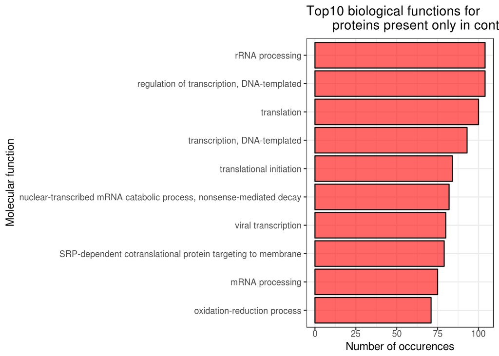

```r
bp_list <- final_data[hgnc_symbol %in% unique_K_RB, bio_process]
bp_list <- bp_list[!duplicated(bp_list)]
total_bp <- data.table(table(unlist(bp_list)))
total_bp <- total_bp[order(total_bp$N, decreasing = T), ]

ggplot(total_bp[1:10], aes(x=reorder(V1,N), N))+
  geom_bar(stat = "identity", colour = "black", fill = "red", alpha = "0.6")+
  labs(title = "Top10 biological functions for
       proteins present only in control",
       x = "Molecular function",
       y = "Number of occurences")+
  theme_grey() %+replace%
  theme(panel.background = element_rect(fill = "white", colour = NA),
        panel.border = element_rect(fill = NA, colour = "grey20"),
        panel.grid.major = element_line(colour = "grey92"),
        panel.grid.minor = element_line(colour = "grey92", size = 0.25),
        strip.background = element_rect(fill = "grey85", colour = "grey20"),
        legend.key = element_rect(fill = "white", colour = NA),
        axis.text.x = element_text(angle = 0, hjust = 0.5),
        complete = TRUE) +
  coord_flip()
```

### Появляются после обработки

```r
unique_RB <- setdiff(RB_dataset[Treatment == "RB", hgnc_symbol], RB_dataset[Treatment == "K", hgnc_symbol])
unique_RB
```

```
##  [1] "SYNCRIP"   "RPS17"     "RPS7"      "SNRPE"     "TUBA1B"
##  [6] "H3F3B"     "EWSR1"     "HNRNPD"    "SF1"       "FSCN1"
## [11] "HRNR"      "CPSF7"     "TAF15"     "HIST1H2AA" "HIST1H2BL"
```

Их всего - 15

Для сети 15 штук - несерьезно Какая-то хрень, будем считать, что их нет

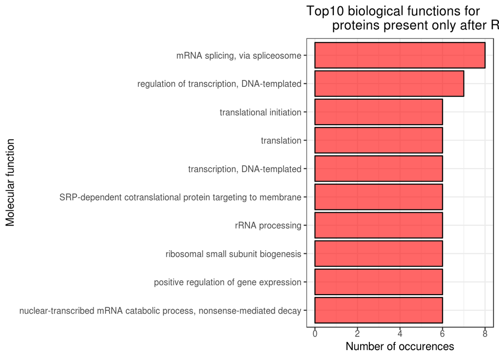

```r
bp_list <- final_data[hgnc_symbol %in% unique_RB, bio_process]
bp_list <- bp_list[!duplicated(bp_list)]
total_bp <- data.table(table(unlist(bp_list)))
total_bp <- total_bp[order(total_bp$N, decreasing = T), ]

ggplot(total_bp[1:10], aes(x=reorder(V1,N), N))+
  geom_bar(stat = "identity", colour = "black", fill = "red", alpha = "0.6")+
  labs(title = "Top10 biological functions for
       proteins present only after RB treatment",
       x = "Molecular function",
       y = "Number of occurences")+
  theme_grey() %+replace%
  theme(panel.background = element_rect(fill = "white", colour = NA),
        panel.border = element_rect(fill = NA, colour = "grey20"),
        panel.grid.major = element_line(colour = "grey92"),
        panel.grid.minor = element_line(colour = "grey92", size = 0.25),
        strip.background = element_rect(fill = "grey85", colour = "grey20"),
        legend.key = element_rect(fill = "white", colour = NA),
        axis.text.x = element_text(angle = 0, hjust = 0.5),
        complete = TRUE) +
  coord_flip()
```

### Ядро-цитоплазма

Значит, агент RB портит что-то в связи, и теперь за PSMA3 пути они не вытаскиваются.

Там на картинке есть 2 кластера плотных во взаимодействиях, и это говорит о том, что у нас есть группы белков, которые участвуют в разных вещах - это трансляция и сплайсинг - и то, и другое завязано на РНК.

Попробуем посмотреть только для цитоплазматические белочки из тех, которые пропадают

```r
temp_K <- RB_dataset[Treatment == "K"]
temp_K <- temp_K[Compartment == "C", hgnc_symbol]

temp_RB <- RB_dataset[Treatment == "RB"]
temp_RB <- temp_RB[Compartment == "C", hgnc_symbol]

unique_K_cp <- setdiff(temp_K, temp_RB)
rm(temp_K, temp_RB)
unique_K_cp
```

```
##   [1] "RBM47"    "AIP"      "DDX3X"    "COPE"     "SCAMP3"   "HNRNPDL"
##   [7] "XPO1"     "PLIN3"    "LPXN"     "PGK1"     "HLA-A"    "HLA-DRA"
##  [13] "HSPB1"    "GNAI2"    "ENO1"     "EPRS"     "ANXA6"    "VIM"
##  [19] "RPSA"     "HNRNPA1"  "ALDOC"    "HSPD1"    "HSPA5"    "MTHFD1"
##  [25] "XRCC5"    "EEF2"     "HLA-DRB1" "LCP1"     "PKM"      "YBX3"
##  [31] "PSMC3"    "RPL7"     "MYL12A"   "NCL"      "MX1"      "PAICS"
##  [37] "UBA1"     "PSMA1"    "EEF1G"    "RPL10"    "CAD"      "CANX"
##  [43] "DNAJA1"   "YWHAB"    "COPB2"    "HSPA9"    "RPS19"    "RPL35"
##  [49] "RPS9"     "RPS5"     "CAPZB"    "PRRC2A"   "LMAN1"    "NASP"
##  [55] "FASN"     "CCT8"     "RAB7A"    "COPA"     "CSE1L"    "TPI1"
##  [61] "ACTB"     "RAB14"    "RAP1B"    "RPS3A"    "RPL26"    "YWHAG"
##  [67] "RPS16"    "RPS18"    "RPS13"    "RPS4X"    "RAN"      "EEF1A1"
##  [73] "TUBA4A"   "HBA2"     "PURA"     "EIF4G1"   "PRDX1"    "BAX"
##  [79] "TRAP1"    "PSMD2"    "TRIM28"   "EIF4A2"   "KPNB1"    "PSMD6"
##  [85] "PDIA6"    "PMVK"     "PCBP2"    "NSDHL"    "RAB11B"   "PDCD4"
##  [91] "UBAP2"    "ECPAS"    "ATL3"     "TUBA1A"   "FERMT3"   "CARM1"
##  [97] "NUDCD3"   "GCN1"     "ABHD14B"  "XRN2"     "LDAH"     "ATXN10"
## [103] "PSME2"    "CORO1C"   "RUVBL2"   "EIF3L"    "RUVBL1"   "NUDC"
## [109] "LUC7L2"   "COPG1"
```

Их всего - 110

Что тут у нас?

https://string-db.org/cgi/network.pl?taskId=nHuSBTMt7dfQ - рибосомные белки всякие И белки на экспорт из клетки!

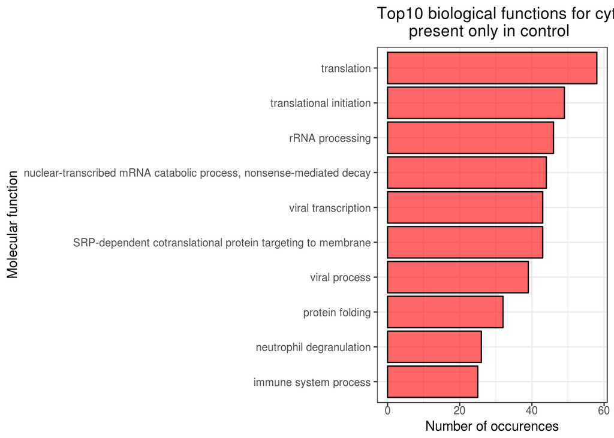

```r
bp_list <- final_data[hgnc_symbol %in% unique_K_cp, bio_process]
bp_list <- bp_list[!duplicated(bp_list)]
total_bp <- data.table(table(unlist(bp_list)))
total_bp <- total_bp[order(total_bp$N, decreasing = T), ]

ggplot(total_bp[1:10], aes(x=reorder(V1,N), N))+
  geom_bar(stat = "identity", colour = "black", fill = "red", alpha = "0.6")+
  labs(title = "Top10 biological functions for cytoplasmic proteins
       present only in control",
       x = "Molecular function",
       y = "Number of occurences")+
  theme_grey() %+replace%
  theme(panel.background = element_rect(fill = "white", colour = NA),
        panel.border = element_rect(fill = NA, colour = "grey20"),
        panel.grid.major = element_line(colour = "grey92"),
        panel.grid.minor = element_line(colour = "grey92", size = 0.25),
        strip.background = element_rect(fill = "grey85", colour = "grey20"),
        legend.key = element_rect(fill = "white", colour = NA),
        axis.text.x = element_text(angle = 0, hjust = 0.5),
        complete = TRUE) +
  coord_flip()
```

Попробуем посмотреть только на ядерные белочки из тех, которые пропадают

```r
temp_K <- RB_dataset[Treatment == "K"]
temp_K <- temp_K[Compartment == "N", hgnc_symbol]

temp_RB <- RB_dataset[Treatment == "RB"]
temp_RB <- temp_RB[Compartment == "N", hgnc_symbol]

unique_K_nuc <- setdiff(temp_K, temp_RB)
rm(temp_K, temp_RB)
unique_K_nuc
```

```
##   [1] "MYO1G"     "PGRMC1"    "SCAMP3"    "UQCRQ"     "HNRNPDL"
##   [6] "PGRMC2"    "DHX15"     "CYB5B"     "PHGDH"     "NDUFA2"
##  [11] "LANCL1"    "IDH3B"     "CTNND1"    "NDUFS2"    "H2AFY"
##  [16] "SEC22B"    "PSIP1"     "NDUFS3"    "SF3B1"     "SNRNP200"
##  [21] "NUP155"    "RSL1D1"    "MTA2"      "TOMM70"    "PRPF6"
##  [26] "LETM1"     "AP2A1"     "AIFM1"     "NDUFB10"   "TOMM40"
##  [31] "CYB5A"     "GLUD1"     "MT-CO2"    "HLA-A"     "HLA-DRA"
##  [36] "TFRC"      "VTN"       "HLA-DPB1"  "RPN1"      "RPN2"
##  [41] "GNAI2"     "ATP1A1"    "SLC25A5"   "RPLP1"     "ATP5F1B"
##  [46] "FCER2"     "TUBB"      "SLC3A2"    "HSP90AB1"  "CYC1"
##  [51] "PTPRC"     "SNRPB2"    "VIM"       "RPSA"      "CD48"
##  [56] "PARP1"     "HIST1H1E"  "HSPD1"     "HSPA5"     "XRCC6"
##  [61] "XRCC5"     "COX4I1"    "EEF2"      "HLA-DRB1"  "LCP1"
##  [66] "CD59"      "HSP90B1"   "HNRNPL"    "HIST1H1B"  "POR"
##  [71] "ATP2A2"    "DDX5"      "RPL7"      "HLA-B"     "RCC1"
```

[output cut: 40 more lines]

Их всего - 273

Вот сетка для них https://string-db.org/cgi/network.pl?taskId=W9tJPdoFDqEB - я убрал опять UBA52

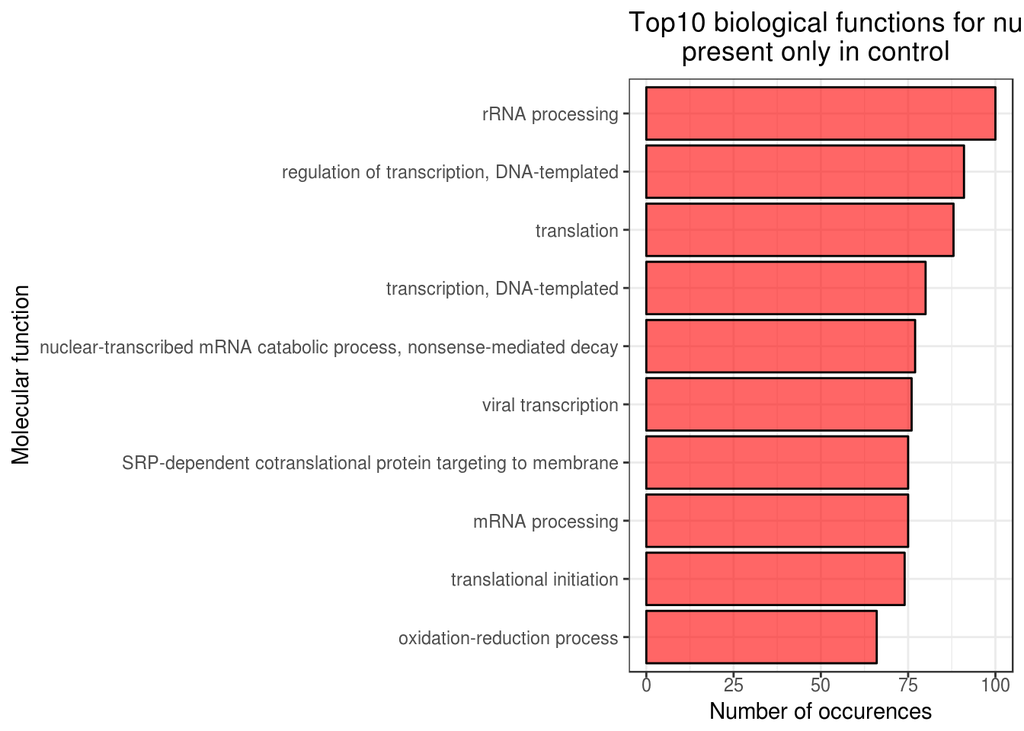

```r
bp_list <- final_data[hgnc_symbol %in% unique_K_nuc, bio_process]
bp_list <- bp_list[!duplicated(bp_list)]
total_bp <- data.table(table(unlist(bp_list)))
total_bp <- total_bp[order(total_bp$N, decreasing = T), ]

ggplot(total_bp[1:10], aes(x=reorder(V1, N), N))+
  geom_bar(stat = "identity", colour = "black", fill = "red", alpha = "0.6")+
  labs(title = "Top10 biological functions for nuclear proteins
       present only in control",
       x = "Molecular function",
       y = "Number of occurences")+
  theme_grey() %+replace%
  theme(panel.background = element_rect(fill = "white", colour = NA),
        panel.border = element_rect(fill = NA, colour = "grey20"),
        panel.grid.major = element_line(colour = "grey92"),
        panel.grid.minor = element_line(colour = "grey92", size = 0.25),
        strip.background = element_rect(fill = "grey85", colour = "grey20"),
        legend.key = element_rect(fill = "white", colour = NA),
        axis.text.x = element_text(angle = 0, hjust = 0.5),
        complete = TRUE) +
  coord_flip()
```

### Вывод

Очень-очень похоже на предыдущую пробу, но белочки чуть другие Такое ощущение, что вещества действуют примерно одинаково

## FC обработка

### Общие для контроля и опыта белочки.

```r
common_FC <- intersect(FC_dataset[Treatment == "K", hgnc_symbol],
                        FC_dataset[Treatment == "FC", hgnc_symbol])
common_FC
```

```
##   [1] "MYO1G"     "DDX3X"     "UQCRQ"     "HNRNPDL"   "DHX15"
##   [6] "HNRNPR"    "LANCL1"    "IDH3B"     "H2AFY"     "NDUFS3"
##  [11] "SNRNP200"  "TOMM70"    "NDUFB10"   "TOMM40"    "GLUD1"
##  [16] "MT-CO2"    "HLA-A"     "HLA-DRA"   "LMNA"      "HLA-DPB1"
##  [21] "HSPB1"     "RPN1"      "RPN2"      "GNAI2"     "ATP1A1"
##  [26] "SLC25A5"   "ATP5F1B"   "FCER2"     "NPM1"      "TUBB"
##  [31] "HSP90AA1"  "HNRNPC"    "HSP90AB1"  "CYC1"      "SNRNP70"
##  [36] "VIM"       "RPSA"      "HNRNPA1"   "PARP1"     "HSPD1"
##  [41] "HSPA5"     "HSPA8"     "PABPC1"    "XRCC6"     "XRCC5"
##  [46] "COX4I1"    "HLA-DRB1"  "LCP1"      "HSP90B1"   "RPS2"
##  [51] "CBR1"      "HIST1H1B"  "ATP2A2"    "DDX5"      "RPL7"
##  [56] "HLA-B"     "NCL"       "MX1"       "LMNB1"     "FLNA"
##  [61] "VDAC1"     "FBL"       "HNRNPA2B1" "UQCRC2"    "SFPQ"
##  [66] "ATP5PB"    "ATP5F1A"   "PSMA3"     "RPL13"     "PTBP1"
##  [71] "EEF1G"     "CANX"      "RPL12"     "PDIA3"     "UQCRC1"
```

[output cut: 20 more lines]

Их много, в отличие от прошлых разов - аж 173 штук!

Построим для них сетку https://string-db.org/cgi/network.pl?taskId=txy4YjtyEyts

То есть получается, что те взаимодействия, которые изменялись при тех обработках, здесь остаются константными

[figure not shown]

```r
bp_list <- final_data[hgnc_symbol %in% common_FC, bio_process]
bp_list <- bp_list[!duplicated(bp_list)]
total_bp <- data.table(table(unlist(bp_list)))
total_bp <- total_bp[order(total_bp$N, decreasing = T), ]

ggplot(total_bp[1:10], aes(x=reorder(V1,N), N))+
  geom_bar(stat = "identity", colour = "black", fill = "cyan", alpha = "0.6")+
  labs(title = "Top10 biological functions for common proteins, from
       RB treatment and control",
       x = "Molecular function",
       y = "Number of occurences")+
  theme_grey() %+replace%
  theme(panel.background = element_rect(fill = "white", colour = NA),
        panel.border = element_rect(fill = NA, colour = "grey20"),
        panel.grid.major = element_line(colour = "grey92"),
        panel.grid.minor = element_line(colour = "grey92", size = 0.25),
        strip.background = element_rect(fill = "grey85", colour = "grey20"),
        legend.key = element_rect(fill = "white", colour = NA),
        axis.text.x = element_text(angle = 0, hjust = 0.5),
        complete = TRUE) +
  coord_flip()
```

### Пропадают после обработки

```r
unique_K <- setdiff(FC_dataset[Treatment == "K", hgnc_symbol], FC_dataset[Treatment == "FC", hgnc_symbol])
unique_K
```

```
##   [1] "RBM47"    "AIP"      "PGRMC1"   "COPE"     "SCAMP3"   "XPO1"
##   [7] "PGRMC2"   "CYB5B"    "PHGDH"    "NDUFA2"   "NUDT21"   "PLIN3"
##  [13] "LPXN"     "CTNND1"   "NDUFS2"   "SEC22B"   "PSIP1"    "SF3B1"
##  [19] "NUP155"   "RSL1D1"   "MTA2"     "PRPF6"    "LETM1"    "AP2A1"
##  [25] "AIFM1"    "CYB5A"    "PGK1"     "TFRC"     "VTN"      "RPLP1"
##  [31] "ENO1"     "EPRS"     "ANXA6"    "SLC3A2"   "PTPRC"    "SNRPB2"
##  [37] "CD48"     "ALDOC"    "HIST1H1E" "MTHFD1"   "EEF2"     "CD59"
##  [43] "PKM"      "HNRNPL"   "POR"      "YBX3"     "PSMC3"    "RCC1"
##  [49] "MYL12A"   "NDUFV2"   "M6PR"     "FGFR2"    "SDHB"     "PAICS"
##  [55] "UBA1"     "PSMA1"    "U2AF2"    "RPL10"    "CAD"      "CALR"
##  [61] "NDUFS1"   "PML"      "PRDX3"    "HLA-F"    "HMOX2"    "SDHA"
##  [67] "DNAJA1"   "HNRNPH1"  "YWHAB"    "PYCR1"    "LSP1"     "RFC4"
##  [73] "PPP1CC"   "FDFT1"    "MTREX"    "RPL35"    "SLC1A4"   "SSR1"
##  [79] "RPL5"     "STT3A"    "CAPZB"    "UQCRFS1"  "ATP5PO"   "PRRC2A"
##  [85] "LMAN1"    "NASP"     "FASN"     "CCT3"     "MRPL19"   "BCAP31"
```

[output cut: 19 more lines]

Ого, Cколько их! их аж 201 штуки!

Что у нас в STRING для этих ребят есть?

https://string-db.org/cgi/network.pl?taskId=C0sdSOt8wxoo - опять удалил убиквитин

Их много, много РНК-связывания. Здесь снова 2 кластера, но они уже другие по составу белков

И нет того белка, связующего 2 кластера

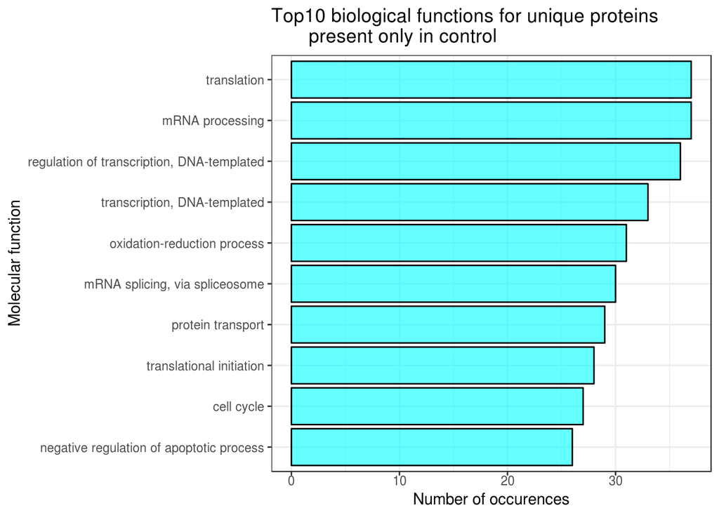

```r
bp_list <- final_data[hgnc_symbol %in% unique_K, bio_process]
bp_list <- bp_list[!duplicated(bp_list)]
total_bp <- data.table(table(unlist(bp_list)))
total_bp <- total_bp[order(total_bp$N, decreasing = T), ]

ggplot(total_bp[1:10], aes(x=reorder(V1,N), N))+
  geom_bar(stat = "identity", colour = "black", fill = "cyan", alpha = "0.6")+
  labs(title = "Top10 biological functions for unique proteins
       present only in control",
       x = "Molecular function",
       y = "Number of occurences")+
  theme_grey() %+replace%
  theme(panel.background = element_rect(fill = "white", colour = NA),
        panel.border = element_rect(fill = NA, colour = "grey20"),
        panel.grid.major = element_line(colour = "grey92"),
        panel.grid.minor = element_line(colour = "grey92", size = 0.25),
        strip.background = element_rect(fill = "grey85", colour = "grey20"),
        legend.key = element_rect(fill = "white", colour = NA),
        axis.text.x = element_text(angle = 0, hjust = 0.5),
        complete = TRUE) +
  coord_flip()
```

### Появляются после обработки

```r
unique_FC <- setdiff(FC_dataset[Treatment == "FC", hgnc_symbol], FC_dataset[Treatment == "K", hgnc_symbol])
unique_FC
```

```
##  [1] "NOP56"     "MYL12B"    "ACTN4"     "SMARCA5"   "P4HB"
##  [6] "SNRPA"     "TOP1"      "SLC25A6"   "SNRPB"     "HIST1H1C"
## [11] "RPS3"      "EEF1B2"    "AK4"       "HIST1H2BB" "RDX"
## [16] "HNRNPF"    "HIST1H2BC" "YBX1"      "EWSR1"     "SPCS2"
## [21] "FSCN1"     "H2AFV"     "RAB43"     "HRNR"      "PREX1"
## [26] "DDX17"     "RBM14"     "HSD17B10"  "TUBA1C"    "RBM4"
## [31] "RTN4"      "NHP2"      "ACTR3B"
```

Их всего - 33 - это немного, но хоть что-то

Глянем по msigdb их функции

Gene Set Name FDR q-value GO_POLY_A_RNA_BINDING 2.79E-18 GO_RNA_BINDING 1.19E-17 PUJANA_CHEK2_PCC_NETWORK 4.73E-10 GO_RIBONUCLEOPROTEIN_COMPLEX 4.98E-9 CAIRO_HEPATOBLASTOMA_CLASSES_UP 2.19E-8 GO_RNA_PROCESSING 3.61E-7 GO_NUCLEOLUS 3.66E-7 PUJANA_ATM_PCC_NETWORK 3.41E-6 GO_PROTEIN_COMPLEX_SUBUNIT_ORGANIZATION 5.56E-6

Это забавно, что там актинин, ядрышко, и рнк

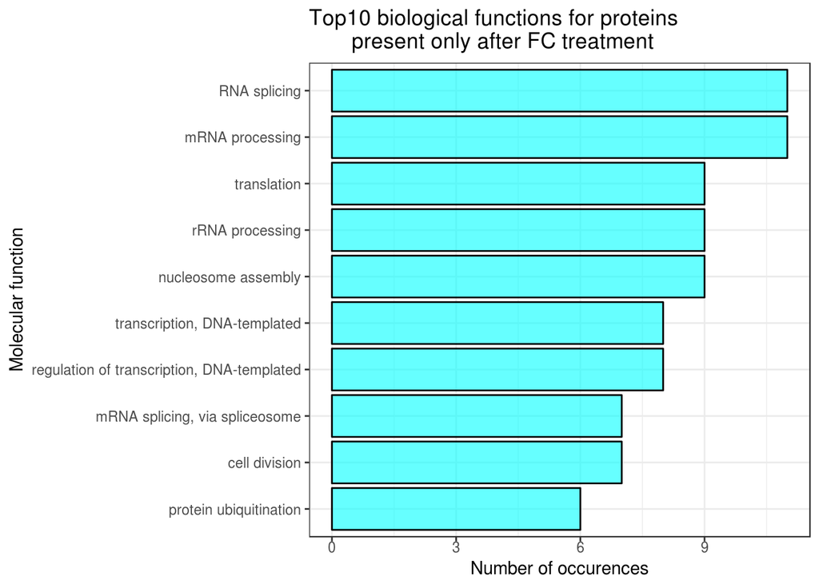

```r
bp_list <- final_data[hgnc_symbol %in% unique_FC, bio_process]
bp_list <- bp_list[!duplicated(bp_list)]
total_bp <- data.table(table(unlist(bp_list)))
total_bp <- total_bp[order(total_bp$N, decreasing = T), ]

ggplot(total_bp[1:10], aes(x=reorder(V1,N), N))+
  geom_bar(stat = "identity", colour = "black", fill = "cyan", alpha = "0.6")+
  labs(title = "Top10 biological functions for proteins
       present only after FC treatment",
       x = "Molecular function",
       y = "Number of occurences")+
  theme_grey() %+replace%
  theme(panel.background = element_rect(fill = "white", colour = NA),
        panel.border = element_rect(fill = NA, colour = "grey20"),
        panel.grid.major = element_line(colour = "grey92"),
        panel.grid.minor = element_line(colour = "grey92", size = 0.25),
        strip.background = element_rect(fill = "grey85", colour = "grey20"),
        legend.key = element_rect(fill = "white", colour = NA),
        axis.text.x = element_text(angle = 0, hjust = 0.5),
        complete = TRUE) +
  coord_flip()
```

### Ядро-цитоплазма

Попробуем посмотреть только для цитоплазматические белочки из тех, которые пропадают

```r
temp_K <- FC_dataset[Treatment == "K"]
temp_K <- temp_K[Compartment == "C", hgnc_symbol]

temp_FC <- FC_dataset[Treatment == "FC"]
temp_FC <- temp_FC[Compartment == "C", hgnc_symbol]

unique_K_cp <- setdiff(temp_K, temp_FC)
rm(temp_K, temp_FC)
unique_K_cp
```

```
##  [1] "RBM47"    "AIP"      "DDX3X"    "COPE"     "SCAMP3"   "HNRNPDL"
##  [7] "XPO1"     "PLIN3"    "LPXN"     "PGK1"     "GNAI2"    "ENO1"
## [13] "EPRS"     "HSP90AA1" "ANXA6"    "ALDOC"    "HSPD1"    "HSPA5"
## [19] "MTHFD1"   "XRCC5"    "EEF2"     "PKM"      "RPS2"     "YBX3"
## [25] "PSMC3"    "RPL7"     "MYL12A"   "NCL"      "PAICS"    "UBA1"
## [31] "PSMA1"    "RPL10"    "CAD"      "CANX"     "DNAJA1"   "HNRNPH1"
## [37] "YWHAB"    "HSPA9"    "RPS19"    "RPL35"    "RPS9"     "CAPZB"
## [43] "PRRC2A"   "LMAN1"    "NASP"     "FASN"     "COPA"     "TPI1"
## [49] "RAB14"    "RAP1B"    "RPS3A"    "RPL26"    "YWHAG"    "RPS16"
## [55] "RPS18"    "RPS13"    "RPS4X"    "RAN"      "TUBB4B"   "EIF4G2"
## [61] "PURA"     "EIF4G1"   "PRDX1"    "BAX"      "TRAP1"    "PSMD2"
## [67] "TRIM28"   "TUBA3C"   "EIF3A"    "EIF4A2"   "PSMD6"    "PDIA6"
## [73] "PMVK"     "PCBP2"    "NSDHL"    "PDCD4"    "ECPAS"    "ATL3"
## [79] "FERMT3"   "CARM1"    "NUDCD3"   "GCN1"     "ABHD14B"  "EIF3C"
## [85] "SRRT"     "XRN2"     "LDAH"     "ATXN10"   "CORO1C"   "RUVBL2"
## [91] "EIF3L"    "RUVBL1"   "NUDC"     "LUC7L2"   "COPG1"
```

Их всего - 95

Вот тебе картинка - тут только трансляция

https://string-db.org/cgi/network.pl?taskId=ff8Uzlp622z1

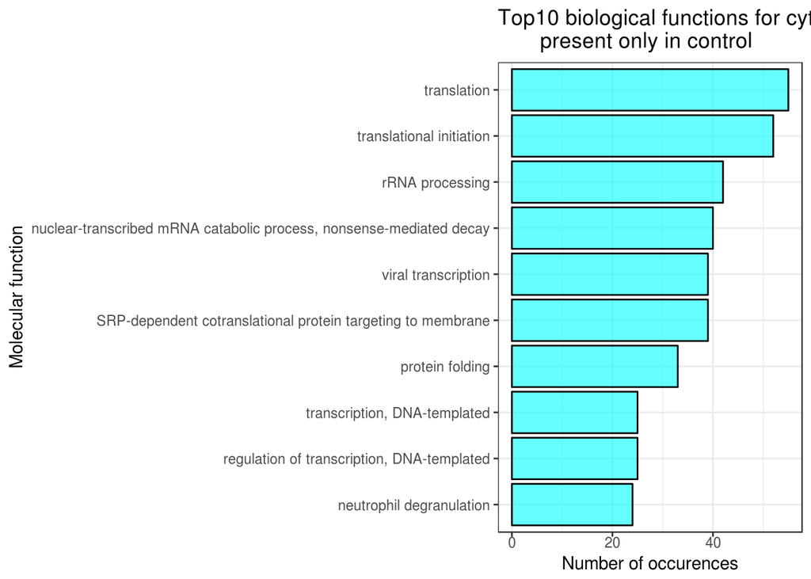

```r
bp_list <- final_data[hgnc_symbol %in% unique_K_cp, bio_process]
bp_list <- bp_list[!duplicated(bp_list)]
total_bp <- data.table(table(unlist(bp_list)))
total_bp <- total_bp[order(total_bp$N, decreasing = T), ]

ggplot(total_bp[1:10], aes(x=reorder(V1,N), N))+
  geom_bar(stat = "identity", colour = "black", fill = "cyan", alpha = "0.6")+
  labs(title = "Top10 biological functions for cytoplasmic proteins
       present only in control",
       x = "Molecular function",
       y = "Number of occurences")+
  theme_grey() %+replace%
  theme(panel.background = element_rect(fill = "white", colour = NA),
        panel.border = element_rect(fill = NA, colour = "grey20"),
        panel.grid.major = element_line(colour = "grey92"),
        panel.grid.minor = element_line(colour = "grey92", size = 0.25),
        strip.background = element_rect(fill = "grey85", colour = "grey20"),
        legend.key = element_rect(fill = "white", colour = NA),
        axis.text.x = element_text(angle = 0, hjust = 0.5),
        complete = TRUE) +
  coord_flip()
```

Теперь cделаем только для ядерных белочков

```r
temp_K <- FC_dataset[Treatment == "K"]
temp_K <- temp_K[Compartment == "N", hgnc_symbol]

temp_FC <- FC_dataset[Treatment == "FC"]
temp_FC <- temp_FC[Compartment == "N", hgnc_symbol]

unique_K_nuc <- setdiff(temp_K, temp_FC)
rm(temp_K, temp_FC)
unique_K_nuc
```

```
##   [1] "PGRMC1"   "SCAMP3"   "PGRMC2"   "CYB5B"    "PHGDH"    "NDUFA2"
##   [7] "NUDT21"   "CTNND1"   "NDUFS2"   "SEC22B"   "PSIP1"    "SF3B1"
##  [13] "NUP155"   "RSL1D1"   "MTA2"     "PRPF6"    "LETM1"    "AP2A1"
##  [19] "AIFM1"    "CYB5A"    "TFRC"     "VTN"      "RPLP1"    "SLC3A2"
##  [25] "PTPRC"    "SNRPB2"   "CD48"     "HIST1H1E" "EEF2"     "CD59"
##  [31] "HNRNPL"   "POR"      "RCC1"     "MYL12A"   "NDUFV2"   "MX1"
##  [37] "M6PR"     "FLNA"     "FGFR2"    "SDHB"     "U2AF2"    "RPL10"
##  [43] "CALR"     "NDUFS1"   "PML"      "PRDX3"    "HLA-F"    "HMOX2"
##  [49] "SDHA"     "HNRNPH1"  "PYCR1"    "LSP1"     "RFC4"     "PPP1CC"
##  [55] "FDFT1"    "MTREX"    "RPL35"    "SLC1A4"   "SSR1"     "RPL5"
##  [61] "STT3A"    "UQCRFS1"  "ATP5PO"   "LMAN1"    "CCT3"     "MRPL19"
##  [67] "CCT8"     "BCAP31"   "HSD17B4"  "COPA"     "AK2"      "NAPA"
##  [73] "ADAR"     "TMEM33"   "RAB10"    "RPS3A"    "RPS18"    "RAP1A"
##  [79] "RPS28"    "UBA52"    "TRA2B"    "RACK1"    "ACTG1"    "GTF2I"
##  [85] "SLC25A3"  "CLTC"     "SRSF2"    "TAP1"     "EXOSC9"   "KHDRBS1"
##  [91] "RBBP4"    "GALNT2"   "TBL3"     "ILF2"     "LMAN2"    "TARDBP"
##  [97] "HNRNPA0"  "RBM39"    "SMC1A"    "LBR"      "CHD4"     "EFTUD2"
## [103] "RAB11B"   "IFI16"    "DECR1"    "NOMO2"    "TUBA1A"   "MTDH"
## [109] "WDR36"    "SMARCC2"  "RDH11"    "STT3B"    "DDX54"    "NUP210"
## [115] "LPGAT1"   "RAB8B"    "CCDC47"   "PYCR2"    "CYFIP2"   "DDX27"
## [121] "DDRGK1"   "CDK5RAP3" "HNRNPAB"  "VRK1"     "NIPSNAP1" "APOL2"
## [127] "MYBBP1A"  "ESYT1"    "DERL1"    "TMED9"    "API5"     "TOMM22"
## [133] "PDS5B"    "AGPAT5"   "TECR"     "SRP68"    "NDUFA12"  "SLC25A13"
## [139] "CPSF3"    "PSME2"    "PA2G4"    "RUVBL1"   "VDAC3"    "WBP11"
## [145] "LUC7L2"   "HYOU1"    "TRPV2"    "SQOR"
```

https://string-db.org/cgi/network.pl?taskId=bBQhdQ5DvTTK - я удалил из состава вершин убиквитин, потому что он ко всему лепится Кластеры отличаются от тех 2 других веществ

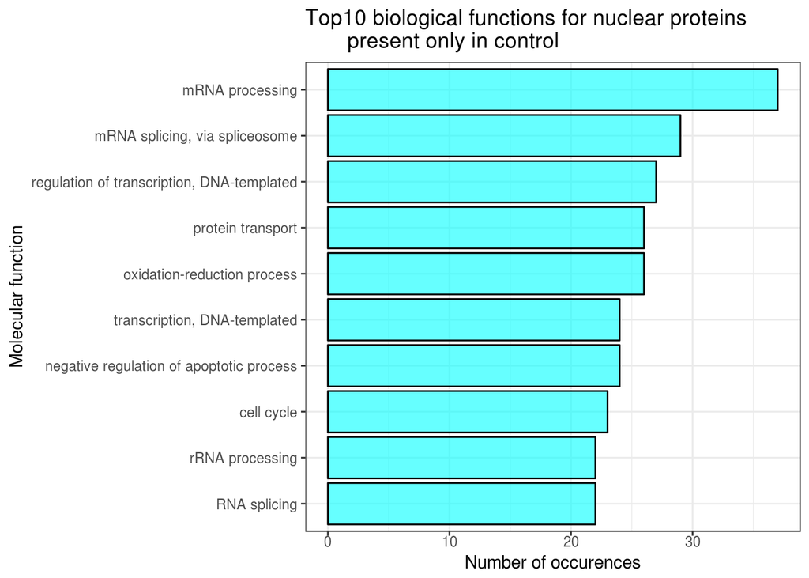

```r
bp_list <- final_data[hgnc_symbol %in% unique_K_nuc, bio_process]
bp_list <- bp_list[!duplicated(bp_list)]
total_bp <- data.table(table(unlist(bp_list)))
total_bp <- total_bp[order(total_bp$N, decreasing = T), ]

ggplot(total_bp[1:10], aes(x=reorder(V1,N), N))+
  geom_bar(stat = "identity", colour = "black", fill = "cyan", alpha = "0.6")+
  labs(title = "Top10 biological functions for nuclear proteins
       present only in control",
       x = "Molecular function",
       y = "Number of occurences")+
  theme_grey() %+replace%
  theme(panel.background = element_rect(fill = "white", colour = NA),
        panel.border = element_rect(fill = NA, colour = "grey20"),
        panel.grid.major = element_line(colour = "grey92"),
        panel.grid.minor = element_line(colour = "grey92", size = 0.25),
        strip.background = element_rect(fill = "grey85", colour = "grey20"),
        legend.key = element_rect(fill = "white", colour = NA),
        axis.text.x = element_text(angle = 0, hjust = 0.5),
        complete = TRUE) +
  coord_flip()
```

### Вывод

Действует на ядрышко и синтез рибосом, наверное

Как работает FC? Точно не на тот белок, который для тех 2 соединений общий, это факт, может, на EEF2?

## Глобальный вывод

FC отличается по эффекту, оказываемому на протеом, и действует на другой белок Все вещества портят трансляцию и связывание с РНК-связывающими белками

Вот так